# Results: Program 5

Table 1: Baseline Demographics by Treatment

[output not shown]

Data Source: Colon Cancer Study

Kaplan-Meier Survival Estimates by Treatment

The LIFETEST Procedure

| Summary of the Number of Censored and Uncensored Values Stratum | Summary of the Number of Censored and Uncensored Values rx | Summary of the Number of Censored and Uncensored Values Total | Summary of the Number of Censored and Uncensored Values Failed | Summary of the Number of Censored and Uncensored Values Censored | Summary of the Number of Censored and Uncensored Values Percent Censored |
| --- | --- | --- | --- | --- | --- |
| 1 | Lev | 310 | 161 | 149 | 48.06 |
| 2 | Lev+5FU | 304 | 123 | 181 | 59.54 |
| 3 | Obs | 315 | 168 | 147 | 46.67 |
| Total |  | 929 | 452 | 477 | 51.35 |

Kaplan-Meier Survival Estimates by Treatment

The LIFETEST Procedure

Testing Homogeneity of Survival Curves for time_num over Strata

| Rank Statistics rx | Rank Statistics Log-Rank |
| --- | --- |
| Lev | 14.921 |
| Lev+5FU | -34.493 |
| Obs | 19.572 |

| Covariance Matrix for the Log-Rank Statistics rx | Covariance Matrix for the Log-Rank Statistics Lev | Covariance Matrix for the Log-Rank Statistics Lev+5FU | Covariance Matrix for the Log-Rank Statistics Obs |
| --- | --- | --- | --- |
| Lev | 98.790 | -50.809 | -47.981 |
| Lev+5FU | -50.809 | 102.407 | -51.598 |
| Obs | -47.981 | -51.598 | 99.579 |

| Test of Equality over Strata Test | Test of Equality over Strata Chi-Square | Test of Equality over Strata DF | Test of Equality over Strata Pr > Chi-Square |
| --- | --- | --- | --- |
| Log-Rank | 11.6831 | 2 | 0.0029 |

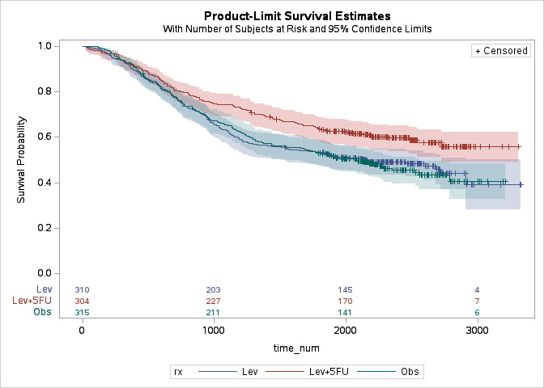

Cox Proportional Hazards Model Results

The PHREG Procedure

| Model Information |  |
| --- | --- |
| Data Set | WORK.COLONDEATH |
| Dependent Variable | time_num |
| Censoring Variable | status_num |
| Censoring Value(s) | 0 |
| Ties Handling | BRESLOW |

| Number of Observations Read Number of Observations Used | 929 911 |
| --- | --- |

| Class Level Information Class | Class Level Information Value | Class Level Information Design Variables | Class Level Information Design Variables |
| --- | --- | --- | --- |
| rx | Lev | 1 | 0 |
|  | Lev+5FU | 0 | 1 |
|  | Obs | 0 | 0 |
| sex | 0 | 0 |  |
|  | 1 | 1 |  |

| Summary of the Number of Event and Censored Values Total | Summary of the Number of Event and Censored Values Event | Summary of the Number of Event and Censored Values Censored | Summary of the Number of Event and Censored Values Percent Censored |
| --- | --- | --- | --- |
| 911 | 441 | 470 | 51.59 |

| Convergence Status |
| --- |
| Convergence criterion (GCONV=1E-8) satisfied. |

| Model Fit Statistics Criterion | Model Fit Statistics Without Covariates | Model Fit Statistics With Covariates |
| --- | --- | --- |
| -2 LOG L | 5700.726 | 5613.011 |
| AIC | 5700.726 | 5623.011 |
| SBC | 5700.726 | 5643.456 |

| Testing Global Null Hypothesis: BETA=0 Test | Testing Global Null Hypothesis: BETA=0 Chi-Square | Testing Global Null Hypothesis: BETA=0 DF | Testing Global Null Hypothesis: BETA=0 Pr > ChiSq |
| --- | --- | --- | --- |
| Likelihood Ratio | 87.7153 | 5 | <.0001 |
| Score | 124.8451 | 5 | <.0001 |
| Wald | 123.0923 | 5 | <.0001 |

| Type 3 Tests Effect | Type 3 Tests DF | Type 3 Tests Wald Chi-Square | Type 3 Tests Pr > ChiSq |
| --- | --- | --- | --- |
| rx | 2 | 11.8811 | 0.0026 |
| age | 1 | 1.7343 | 0.1879 |
| sex | 1 | 0.0866 | 0.7685 |
| nodes_num | 1 | 109.3828 | <.0001 |

| Analysis of Maximum Likelihood Estimates Parameter | Analysis of Maximum Likelihood Estimates | Analysis of Maximum Likelihood Estimates DF | Analysis of Maximum Likelihood Estimates Parameter Estimate | Analysis of Maximum Likelihood Estimates Standard Error | Analysis of Maximum Likelihood Estimates Chi-Square | Analysis of Maximum Likelihood Estimates Pr > ChiSq | Analysis of Maximum Likelihood Estimates Hazard Ratio | Analysis of Maximum Likelihood Estimates Label |
| --- | --- | --- | --- | --- | --- | --- | --- | --- |
| rx | Lev | 1 | -0.07988 | 0.11161 | 0.5122 | 0.4742 | 0.923 | rx Lev |
| rx | Lev+5FU | 1 | -0.40237 | 0.12054 | 11.1428 | 0.0008 | 0.669 | rx Lev+5FU |
| age |  | 1 | 0.00533 | 0.00405 | 1.7343 | 0.1879 | 1.005 |  |
| sex | 1 | 1 | -0.02818 | 0.09573 | 0.0866 | 0.7685 | 0.972 | sex 1 |
| nodes_num |  | 1 | 0.09274 | 0.00887 | 109.3828 | <.0001 | 1.097 |  |

| Treatment HRs: Hazard Ratios for rx Description | Treatment HRs: Hazard Ratios for rx Point Estimate | Treatment HRs: Hazard Ratios for rx 95% Wald Confidence Limits | Treatment HRs: Hazard Ratios for rx 95% Wald Confidence Limits | Treatment HRs: Hazard Ratios for rx 95% Profile Likelihood Confidence Limits | Treatment HRs: Hazard Ratios for rx 95% Profile Likelihood Confidence Limits |
| --- | --- | --- | --- | --- | --- |
| rx Lev vs Lev+5FU | 1.381 | 1.086 | 1.755 | 1.087 | 1.758 |
| rx Lev vs Obs | 0.923 | 0.742 | 1.149 | 0.741 | 1.149 |
| rx Lev+5FU vs Obs | 0.669 | 0.528 | 0.847 | 0.527 | 0.846 |

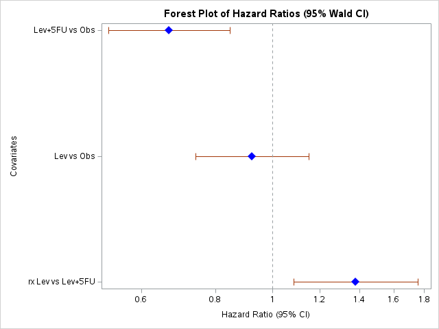

Cox Model with Treatment-by-Nodes Interaction

The PHREG Procedure

| Model Information |  |
| --- | --- |
| Data Set | WORK.COLONDEATH |
| Dependent Variable | time_num |
| Censoring Variable | status_num |
| Censoring Value(s) | 0 |
| Ties Handling | BRESLOW |

| Number of Observations Read Number of Observations Used | 929 911 |
| --- | --- |

| Class Level Information Class | Class Level Information Value | Class Level Information Design Variables | Class Level Information Design Variables |
| --- | --- | --- | --- |
| rx | Lev | 1 | 0 |
|  | Lev+5FU | 0 | 1 |
|  | Obs | 0 | 0 |
| sex | 0 | 0 |  |
|  | 1 | 1 |  |

| Summary of the Number of Event and Censored Values Total | Summary of the Number of Event and Censored Values Event | Summary of the Number of Event and Censored Values Censored | Summary of the Number of Event and Censored Values Percent Censored |
| --- | --- | --- | --- |
| 911 | 441 | 470 | 51.59 |

| Convergence Status |
| --- |
| Convergence criterion (GCONV=1E-8) satisfied. |

| Model Fit Statistics Criterion | Model Fit Statistics Without Covariates | Model Fit Statistics With Covariates |
| --- | --- | --- |
| -2 LOG L | 5700.726 | 5609.765 |
| AIC | 5700.726 | 5623.765 |
| SBC | 5700.726 | 5652.388 |

| Testing Global Null Hypothesis: BETA=0 Test | Testing Global Null Hypothesis: BETA=0 Chi-Square | Testing Global Null Hypothesis: BETA=0 DF | Testing Global Null Hypothesis: BETA=0 Pr > ChiSq |
| --- | --- | --- | --- |
| Likelihood Ratio | 90.9615 | 7 | <.0001 |
| Score | 133.5050 | 7 | <.0001 |
| Wald | 124.7247 | 7 | <.0001 |

| Joint Tests Effect | Joint Tests DF | Joint Tests Wald Chi-Square | Joint Tests Pr > ChiSq |
| --- | --- | --- | --- |
| rx | 2 | 8.7943 | 0.0123 |
| nodes_num | 1 | 56.7710 | <.0001 |
| nodes_num*rx | 2 | 3.1092 | 0.2113 |
| age | 1 | 1.2256 | 0.2683 |
| sex | 1 | 0.0543 | 0.8157 |

Note:Under full-rank parameterizations, Type 3 effect tests are replaced by joint tests. The joint test for an effect is a test that all of the parameters associated with that effect are zero. Such joint tests might not be equivalent to Type 3 effect tests under GLM parameterization.

| Analysis of Maximum Likelihood Estimates Parameter | Analysis of Maximum Likelihood Estimates | Analysis of Maximum Likelihood Estimates DF | Analysis of Maximum Likelihood Estimates Parameter Estimate | Analysis of Maximum Likelihood Estimates Standard Error | Analysis of Maximum Likelihood Estimates Chi-Square | Analysis of Maximum Likelihood Estimates Pr > ChiSq | Analysis of Maximum Likelihood Estimates Hazard Ratio | Analysis of Maximum Likelihood Estimates Label |
| --- | --- | --- | --- | --- | --- | --- | --- | --- |
| rx | Lev | 1 | 0.07504 | 0.14624 | 0.2633 | 0.6079 | . | rx Lev |
| rx | Lev+5FU | 1 | -0.39648 | 0.16594 | 5.7084 | 0.0169 | . | rx Lev+5FU |
| nodes_num |  | 1 | 0.10745 | 0.01426 | 56.7710 | <.0001 | . |  |
| nodes_num*rx | Lev | 1 | -0.03280 | 0.02031 | 2.6078 | 0.1063 | . | rx Lev * nodes_num |
| nodes_num*rx | Lev+5FU | 1 | -0.0006947 | 0.02456 | 0.0008 | 0.9774 | . | rx Lev+5FU * nodes_num |
| age |  | 1 | 0.00451 | 0.00407 | 1.2256 | 0.2683 | 1.005 |  |
| sex | 1 | 1 | -0.02245 | 0.09630 | 0.0543 | 0.8157 | 0.978 | sex 1 |

Survival by Treatment, Stratified by Node Count

The LIFETEST Procedure

Stratum 1: rx = Lev

| Product-Limit Survival Estimates time_num | Product-Limit Survival Estimates | Product-Limit Survival Estimates Survival | Product-Limit Survival Estimates Failure | Product-Limit Survival Estimates Survival Standard Error | Product-Limit Survival Estimates Number Failed | Product-Limit Survival Estimates Number Left |
| --- | --- | --- | --- | --- | --- | --- |
| 0.00 |  | 1.0000 | 0 | 0 | 0 | 304 |
| 24.00 |  | 0.9967 | 0.00329 | 0.00328 | 1 | 303 |
| 56.00 |  | 0.9934 | 0.00658 | 0.00464 | 2 | 302 |
| 93.00 |  | 0.9901 | 0.00987 | 0.00567 | 3 | 301 |
| 122.00 |  | 0.9868 | 0.0132 | 0.00654 | 4 | 300 |
| 129.00 |  | 0.9836 | 0.0164 | 0.00729 | 5 | 299 |
| 133.00 |  | 0.9803 | 0.0197 | 0.00798 | 6 | 298 |
| 150.00 |  | 0.9770 | 0.0230 | 0.00860 | 7 | 297 |
| 165.00 |  | 0.9737 | 0.0263 | 0.00918 | 8 | 296 |
| 171.00 |  | . | . | . | 9 | 295 |
| 171.00 |  | 0.9671 | 0.0329 | 0.0102 | 10 | 294 |
| 191.00 |  | 0.9638 | 0.0362 | 0.0107 | 11 | 293 |
| 206.00 |  | 0.9605 | 0.0395 | 0.0112 | 12 | 292 |
| 219.00 |  | . | . | . | 13 | 291 |
| 219.00 |  | 0.9539 | 0.0461 | 0.0120 | 14 | 290 |
| 222.00 |  | 0.9507 | 0.0493 | 0.0124 | 15 | 289 |
| 226.00 |  | 0.9474 | 0.0526 | 0.0128 | 16 | 288 |
| 232.00 |  | 0.9441 | 0.0559 | 0.0132 | 17 | 287 |
| 257.00 |  | 0.9408 | 0.0592 | 0.0135 | 18 | 286 |
| 283.00 |  | 0.9375 | 0.0625 | 0.0139 | 19 | 285 |
| 314.00 |  | . | . | . | 20 | 284 |
| 314.00 |  | 0.9309 | 0.0691 | 0.0145 | 21 | 283 |
| 316.00 |  | 0.9276 | 0.0724 | 0.0149 | 22 | 282 |
| 323.00 |  | 0.9243 | 0.0757 | 0.0152 | 23 | 281 |
| 342.00 |  | 0.9211 | 0.0789 | 0.0155 | 24 | 280 |
| 343.00 |  | 0.9178 | 0.0822 | 0.0158 | 25 | 279 |
| 349.00 |  | 0.9145 | 0.0855 | 0.0160 | 26 | 278 |
| 355.00 |  | 0.9112 | 0.0888 | 0.0163 | 27 | 277 |
| 356.00 |  | 0.9079 | 0.0921 | 0.0166 | 28 | 276 |
| 362.00 |  | 0.9046 | 0.0954 | 0.0168 | 29 | 275 |

[output cut: 275 more lines]

Note:The marked survival times are censored observations.

Summary Statistics for Time Variable time_num

| Quartile Estimates Percent | Quartile Estimates Point Estimate | Quartile Estimates 95% Confidence Interval Transform | Quartile Estimates 95% Confidence Interval [Lower | Quartile Estimates 95% Confidence Interval Upper) |
| --- | --- | --- | --- | --- |
| 75 | . | LOGLOG | . | . |
| 50 | 2171.00 | LOGLOG | 1548.00 | . |
| 25 | 757.00 | LOGLOG | 647.00 | 909.00 |

| Mean | Standard Error |
| --- | --- |
| 1862.84 | 62.61 |

Note:The mean survival time and its standard error were underestimated because the largest observation was censored and the estimation was restricted to the largest event time.

Survival by Treatment, Stratified by Node Count

The LIFETEST Procedure

Stratum 2: rx = Lev+5FU

| Product-Limit Survival Estimates time_num | Product-Limit Survival Estimates | Product-Limit Survival Estimates Survival | Product-Limit Survival Estimates Failure | Product-Limit Survival Estimates Survival Standard Error | Product-Limit Survival Estimates Number Failed | Product-Limit Survival Estimates Number Left |
| --- | --- | --- | --- | --- | --- | --- |
| 0.00 |  | 1.0000 | 0 | 0 | 0 | 295 |
| 23.00 |  | 0.9966 | 0.00339 | 0.00338 | 1 | 294 |
| 34.00 |  | 0.9932 | 0.00678 | 0.00478 | 2 | 293 |
| 45.00 |  | 0.9898 | 0.0102 | 0.00584 | 3 | 292 |
| 52.00 |  | 0.9864 | 0.0136 | 0.00673 | 4 | 291 |
| 79.00 |  | 0.9831 | 0.0169 | 0.00752 | 5 | 290 |
| 127.00 |  | 0.9797 | 0.0203 | 0.00822 | 6 | 289 |
| 138.00 |  | 0.9763 | 0.0237 | 0.00886 | 7 | 288 |
| 141.00 |  | 0.9729 | 0.0271 | 0.00946 | 8 | 287 |
| 144.00 |  | 0.9695 | 0.0305 | 0.0100 | 9 | 286 |
| 251.00 |  | 0.9661 | 0.0339 | 0.0105 | 10 | 285 |
| 269.00 |  | 0.9627 | 0.0373 | 0.0110 | 11 | 284 |
| 271.00 |  | 0.9593 | 0.0407 | 0.0115 | 12 | 283 |
| 274.00 |  | 0.9559 | 0.0441 | 0.0119 | 13 | 282 |
| 276.00 |  | 0.9525 | 0.0475 | 0.0124 | 14 | 281 |
| 279.00 |  | 0.9492 | 0.0508 | 0.0128 | 15 | 280 |
| 283.00 |  | 0.9458 | 0.0542 | 0.0132 | 16 | 279 |
| 293.00 |  | 0.9424 | 0.0576 | 0.0136 | 17 | 278 |
| 302.00 |  | 0.9390 | 0.0610 | 0.0139 | 18 | 277 |
| 304.00 |  | 0.9356 | 0.0644 | 0.0143 | 19 | 276 |
| 324.00 |  | 0.9322 | 0.0678 | 0.0146 | 20 | 275 |
| 326.00 |  | 0.9288 | 0.0712 | 0.0150 | 21 | 274 |
| 340.00 |  | 0.9254 | 0.0746 | 0.0153 | 22 | 273 |
| 355.00 |  | 0.9220 | 0.0780 | 0.0156 | 23 | 272 |
| 363.00 |  | 0.9186 | 0.0814 | 0.0159 | 24 | 271 |
| 389.00 |  | 0.9153 | 0.0847 | 0.0162 | 25 | 270 |
| 400.00 |  | 0.9119 | 0.0881 | 0.0165 | 26 | 269 |
| 428.00 |  | 0.9085 | 0.0915 | 0.0168 | 27 | 268 |
| 430.00 |  | 0.9051 | 0.0949 | 0.0171 | 28 | 267 |
| 441.00 |  | 0.9017 | 0.0983 | 0.0173 | 29 | 266 |

[output cut: 266 more lines]

Note:The marked survival times are censored observations.

Summary Statistics for Time Variable time_num

| Quartile Estimates Percent | Quartile Estimates Point Estimate | Quartile Estimates 95% Confidence Interval Transform | Quartile Estimates 95% Confidence Interval [Lower | Quartile Estimates 95% Confidence Interval Upper) |
| --- | --- | --- | --- | --- |
| 75 | . | LOGLOG | . | . |
| 50 | . | LOGLOG | 2725.00 | . |
| 25 | 1022.00 | LOGLOG | 802.00 | 1388.00 |

| Mean | Standard Error |
| --- | --- |
| 2005.49 | 55.99 |

Note:The mean survival time and its standard error were underestimated because the largest observation was censored and the estimation was restricted to the largest event time.

Survival by Treatment, Stratified by Node Count

The LIFETEST Procedure

Stratum 3: rx = Obs

| Product-Limit Survival Estimates time_num | Product-Limit Survival Estimates | Product-Limit Survival Estimates Survival | Product-Limit Survival Estimates Failure | Product-Limit Survival Estimates Survival Standard Error | Product-Limit Survival Estimates Number Failed | Product-Limit Survival Estimates Number Left |
| --- | --- | --- | --- | --- | --- | --- |
| 0.00 |  | 1.0000 | 0 | 0 | 0 | 312 |
| 113.00 |  | 0.9968 | 0.00321 | 0.00320 | 1 | 311 |
| 125.00 |  | 0.9936 | 0.00641 | 0.00452 | 2 | 310 |
| 145.00 |  | 0.9904 | 0.00962 | 0.00552 | 3 | 309 |
| 164.00 |  | 0.9872 | 0.0128 | 0.00637 | 4 | 308 |
| 166.00 |  | 0.9840 | 0.0160 | 0.00711 | 5 | 307 |
| 187.00 |  | 0.9808 | 0.0192 | 0.00778 | 6 | 306 |
| 208.00 |  | 0.9776 | 0.0224 | 0.00838 | 7 | 305 |
| 215.00 |  | 0.9744 | 0.0256 | 0.00895 | 8 | 304 |
| 218.00 |  | 0.9712 | 0.0288 | 0.00948 | 9 | 303 |
| 238.00 |  | 0.9679 | 0.0321 | 0.00997 | 10 | 302 |
| 241.00 |  | 0.9647 | 0.0353 | 0.0104 | 11 | 301 |
| 242.00 |  | 0.9615 | 0.0385 | 0.0109 | 12 | 300 |
| 253.00 |  | 0.9583 | 0.0417 | 0.0113 | 13 | 299 |
| 259.00 |  | . | . | . | 14 | 298 |
| 259.00 |  | 0.9519 | 0.0481 | 0.0121 | 15 | 297 |
| 264.00 |  | 0.9487 | 0.0513 | 0.0125 | 16 | 296 |
| 275.00 |  | 0.9455 | 0.0545 | 0.0129 | 17 | 295 |
| 289.00 |  | 0.9423 | 0.0577 | 0.0132 | 18 | 294 |
| 311.00 |  | 0.9391 | 0.0609 | 0.0135 | 19 | 293 |
| 313.00 |  | 0.9359 | 0.0641 | 0.0139 | 20 | 292 |
| 322.00 |  | 0.9327 | 0.0673 | 0.0142 | 21 | 291 |
| 331.00 |  | 0.9295 | 0.0705 | 0.0145 | 22 | 290 |
| 365.00 |  | 0.9263 | 0.0737 | 0.0148 | 23 | 289 |
| 372.00 |  | 0.9231 | 0.0769 | 0.0151 | 24 | 288 |
| 381.00 |  | 0.9199 | 0.0801 | 0.0154 | 25 | 287 |
| 384.00 |  | . | . | . | 26 | 286 |
| 384.00 |  | 0.9135 | 0.0865 | 0.0159 | 27 | 285 |
| 390.00 |  | 0.9103 | 0.0897 | 0.0162 | 28 | 284 |
| 409.00 |  | 0.9071 | 0.0929 | 0.0164 | 29 | 283 |

[output cut: 283 more lines]

Note:The marked survival times are censored observations.

Summary Statistics for Time Variable time_num

| Quartile Estimates Percent | Quartile Estimates Point Estimate | Quartile Estimates 95% Confidence Interval Transform | Quartile Estimates 95% Confidence Interval [Lower | Quartile Estimates 95% Confidence Interval Upper) |
| --- | --- | --- | --- | --- |
| 75 | . | LOGLOG | . | . |
| 50 | 2077.00 | LOGLOG | 1530.00 | 2552.00 |
| 25 | 760.00 | LOGLOG | 663.00 | 924.00 |

| Mean | Standard Error |
| --- | --- |
| 1792.30 | 57.34 |

Note:The mean survival time and its standard error were underestimated because the largest observation was censored and the estimation was restricted to the largest event time.

| Summary of the Number of Censored and Uncensored Values Stratum | Summary of the Number of Censored and Uncensored Values rx | Summary of the Number of Censored and Uncensored Values Total | Summary of the Number of Censored and Uncensored Values Failed | Summary of the Number of Censored and Uncensored Values Censored | Summary of the Number of Censored and Uncensored Values Percent Censored |
| --- | --- | --- | --- | --- | --- |
| 1 | Lev | 304 | 156 | 148 | 48.68 |
| 2 | Lev+5FU | 295 | 118 | 177 | 60.00 |
| 3 | Obs | 312 | 167 | 145 | 46.47 |
| Total |  | 911 | 441 | 470 | 51.59 |

Survival by Treatment, Stratified by Node Count

The LIFETEST Procedure

Testing Homogeneity of Survival Curves for time_num over Strata

| Rank Statistics rx | Rank Statistics Log-Rank | Rank Statistics Wilcoxon |
| --- | --- | --- |
| Lev | 13.252 | 9724 |
| Lev+5FU | -34.396 | -21967 |
| Obs | 21.144 | 12243 |

| Covariance Matrix for the Log-Rank Statistics rx | Covariance Matrix for the Log-Rank Statistics Lev | Covariance Matrix for the Log-Rank Statistics Lev+5FU | Covariance Matrix for the Log-Rank Statistics Obs |
| --- | --- | --- | --- |
| Lev | 96.4728 | -49.2534 | -47.2193 |
| Lev+5FU | -49.2534 | 99.5385 | -50.2851 |
| Obs | -47.2193 | -50.2851 | 97.5044 |

| Covariance Matrix for the Wilcoxon Statistics rx | Covariance Matrix for the Wilcoxon Statistics Lev | Covariance Matrix for the Wilcoxon Statistics Lev+5FU | Covariance Matrix for the Wilcoxon Statistics Obs |
| --- | --- | --- | --- |
| Lev | 46595015 | -2.337E7 | -2.322E7 |
| Lev+5FU | -2.337E7 | 47442460 | -2.407E7 |
| Obs | -2.322E7 | -2.407E7 | 47294999 |

| Test of Equality over Strata Test | Test of Equality over Strata Chi-Square | Test of Equality over Strata DF | Test of Equality over Strata Pr > Chi-Square |
| --- | --- | --- | --- |
| Log-Rank | 12.0827 | 2 | 0.0024 |
| Wilcoxon | 10.2056 | 2 | 0.0061 |
| -2Log(LR) | 13.8051 | 2 | 0.0010 |

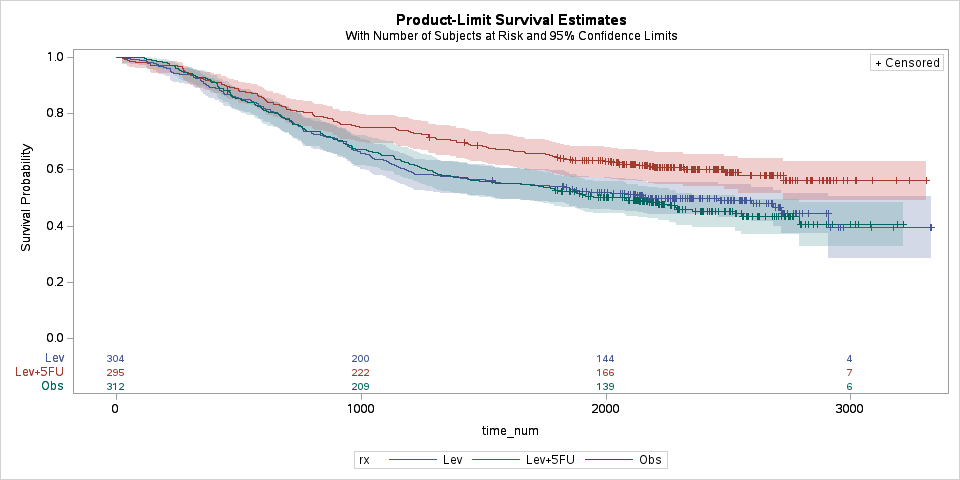

Survival by Treatment, Stratified by Node Count

The LIFETEST Procedure

Stratum 1: rx = Lev

| Product-Limit Survival Estimates time_num | Product-Limit Survival Estimates | Product-Limit Survival Estimates Survival | Product-Limit Survival Estimates Failure | Product-Limit Survival Estimates Survival Standard Error | Product-Limit Survival Estimates Number Failed | Product-Limit Survival Estimates Number Left |
| --- | --- | --- | --- | --- | --- | --- |
| 0.00 |  | 1.0000 | 0 | 0 | 0 | 6 |
| 444.00 |  | 0.8333 | 0.1667 | 0.1521 | 1 | 5 |
| 569.00 |  | 0.6667 | 0.3333 | 0.1925 | 2 | 4 |
| 885.00 |  | 0.5000 | 0.5000 | 0.2041 | 3 | 3 |
| 1061.00 |  | 0.3333 | 0.6667 | 0.1925 | 4 | 2 |
| 1252.00 |  | 0.1667 | 0.8333 | 0.1521 | 5 | 1 |
| 2618.00 | * | . | . | . | 5 | 0 |

Note:The marked survival times are censored observations.

Summary Statistics for Time Variable time_num

| Quartile Estimates Percent | Quartile Estimates Point Estimate | Quartile Estimates 95% Confidence Interval Transform | Quartile Estimates 95% Confidence Interval [Lower | Quartile Estimates 95% Confidence Interval Upper) |
| --- | --- | --- | --- | --- |
| 75 | 1252.00 | LOGLOG | 569.00 | . |
| 50 | 973.00 | LOGLOG | 444.00 | . |
| 25 | 569.00 | LOGLOG | 444.00 | 1061.00 |

| Mean | Standard Error |
| --- | --- |
| 910.50 | 143.23 |

Note:The mean survival time and its standard error were underestimated because the largest observation was censored and the estimation was restricted to the largest event time.

Survival by Treatment, Stratified by Node Count

The LIFETEST Procedure

Stratum 2: rx = Lev+5FU

| Product-Limit Survival Estimates time_num | Product-Limit Survival Estimates | Product-Limit Survival Estimates Survival | Product-Limit Survival Estimates Failure | Product-Limit Survival Estimates Survival Standard Error | Product-Limit Survival Estimates Number Failed | Product-Limit Survival Estimates Number Left |
| --- | --- | --- | --- | --- | --- | --- |
| 0.00 |  | 1.0000 | 0 | 0 | 0 | 9 |
| 186.00 |  | 0.8889 | 0.1111 | 0.1048 | 1 | 8 |
| 490.00 |  | 0.7778 | 0.2222 | 0.1386 | 2 | 7 |
| 583.00 |  | 0.6667 | 0.3333 | 0.1571 | 3 | 6 |
| 643.00 |  | 0.5556 | 0.4444 | 0.1656 | 4 | 5 |
| 1273.00 |  | 0.4444 | 0.5556 | 0.1656 | 5 | 4 |
| 2290.00 | * | . | . | . | 5 | 3 |
| 2362.00 | * | . | . | . | 5 | 2 |
| 2869.00 | * | . | . | . | 5 | 1 |
| 2950.00 | * | . | . | . | 5 | 0 |

Note:The marked survival times are censored observations.

Summary Statistics for Time Variable time_num

| Quartile Estimates Percent | Quartile Estimates Point Estimate | Quartile Estimates 95% Confidence Interval Transform | Quartile Estimates 95% Confidence Interval [Lower | Quartile Estimates 95% Confidence Interval Upper) |
| --- | --- | --- | --- | --- |
| 75 | . | LOGLOG | 643.00 | . |
| 50 | 1273.00 | LOGLOG | 186.00 | . |
| 25 | 583.00 | LOGLOG | 186.00 | 1273.00 |

| Mean | Standard Error |
| --- | --- |
| 918.56 | 154.01 |

Note:The mean survival time and its standard error were underestimated because the largest observation was censored and the estimation was restricted to the largest event time.

Survival by Treatment, Stratified by Node Count

The LIFETEST Procedure

Stratum 3: rx = Obs

| Product-Limit Survival Estimates time_num | Product-Limit Survival Estimates | Product-Limit Survival Estimates Survival | Product-Limit Survival Estimates Failure | Product-Limit Survival Estimates Survival Standard Error | Product-Limit Survival Estimates Number Failed | Product-Limit Survival Estimates Number Left |
| --- | --- | --- | --- | --- | --- | --- |
| 0.00 |  | 1.0000 | 0 | 0 | 0 | 3 |
| 201.00 |  | 0.6667 | 0.3333 | 0.2722 | 1 | 2 |
| 2191.00 | * | . | . | . | 1 | 1 |
| 2257.00 | * | . | . | . | 1 | 0 |

Note:The marked survival times are censored observations.

Summary Statistics for Time Variable time_num

| Quartile Estimates Percent | Quartile Estimates Point Estimate | Quartile Estimates 95% Confidence Interval Transform | Quartile Estimates 95% Confidence Interval [Lower | Quartile Estimates 95% Confidence Interval Upper) |
| --- | --- | --- | --- | --- |
| 75 | . | LOGLOG | 201.00 | . |
| 50 | . | LOGLOG | 201.00 | . |
| 25 | 201.00 | LOGLOG | 201.00 | . |

| Mean | Standard Error |
| --- | --- |
| 201.00 | . |

Note:The mean survival time and its standard error were underestimated because the largest observation was censored and the estimation was restricted to the largest event time.

| Summary of the Number of Censored and Uncensored Values Stratum | Summary of the Number of Censored and Uncensored Values rx | Summary of the Number of Censored and Uncensored Values Total | Summary of the Number of Censored and Uncensored Values Failed | Summary of the Number of Censored and Uncensored Values Censored | Summary of the Number of Censored and Uncensored Values Percent Censored |
| --- | --- | --- | --- | --- | --- |
| 1 | Lev | 6 | 5 | 1 | 16.67 |
| 2 | Lev+5FU | 9 | 5 | 4 | 44.44 |
| 3 | Obs | 3 | 1 | 2 | 66.67 |
| Total |  | 18 | 11 | 7 | 38.89 |

Survival by Treatment, Stratified by Node Count

The LIFETEST Procedure

Testing Homogeneity of Survival Curves for time_num over Strata

| Rank Statistics rx | Rank Statistics Log-Rank | Rank Statistics Wilcoxon |
| --- | --- | --- |
| Lev | 1.5964 | 14.000 |
| Lev+5FU | -0.6775 | -7.000 |
| Obs | -0.9189 | -7.000 |

| Covariance Matrix for the Log-Rank Statistics rx | Covariance Matrix for the Log-Rank Statistics Lev | Covariance Matrix for the Log-Rank Statistics Lev+5FU | Covariance Matrix for the Log-Rank Statistics Obs |
| --- | --- | --- | --- |
| Lev | 2.29564 | -1.72582 | -0.56982 |
| Lev+5FU | -1.72582 | 2.72577 | -0.99994 |
| Obs | -0.56982 | -0.99994 | 1.56976 |

| Covariance Matrix for the Wilcoxon Statistics rx | Covariance Matrix for the Wilcoxon Statistics Lev | Covariance Matrix for the Wilcoxon Statistics Lev+5FU | Covariance Matrix for the Wilcoxon Statistics Obs |
| --- | --- | --- | --- |
| Lev | 431.000 | -327.000 | -104.000 |
| Lev+5FU | -327.000 | 490.000 | -163.000 |
| Obs | -104.000 | -163.000 | 267.000 |

| Test of Equality over Strata Test | Test of Equality over Strata Chi-Square | Test of Equality over Strata DF | Test of Equality over Strata Pr > Chi-Square |
| --- | --- | --- | --- |
| Log-Rank | 1.3013 | 2 | 0.5217 |
| Wilcoxon | 0.5090 | 2 | 0.7753 |
| -2Log(LR) | 1.9396 | 2 | 0.3792 |

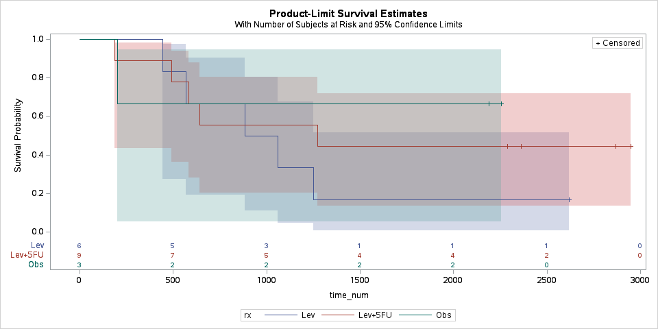